# Data Science Applications: Lecture 3

dplyr for data manipulation - Part I

Josemari Feliciano

Spring 2025 - January 28

## Recap from Lecture 2

1. Data classification
2. Introduction to Quarto
3. Introduction to the ggplot2 package (part of tidyverse packages)

**Note:** ggplot2 is covered in Chapter 1 of your textbook

## Additional ggplot customization

Sample ggplot code:

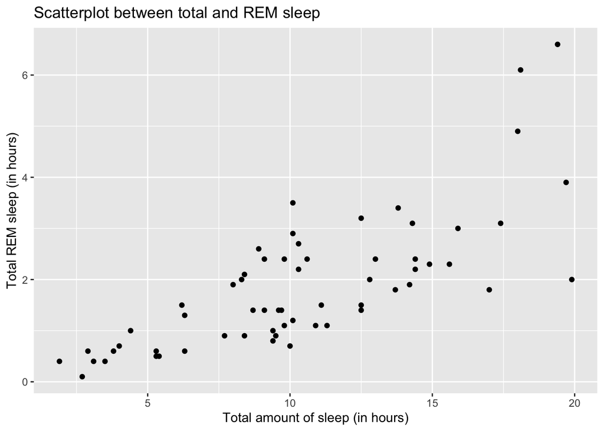

```r
library(tidyverse) # loads tidyverse
data("msleep") # loads built-in dataset into R envt

ggplot(msleep, aes(x = sleep_total, y = sleep_rem)) +
  geom_point() +
  labs(title = "Scatterplot between total and REM sleep",
       x = "Total amount of sleep (in hours)",
       y = "Total REM sleep (in hours)")
```

**Noteworthy further customizations:** Consider the use of theme_minimal() or theme_bw() customizations in your future data visualizations. Not required for this course.

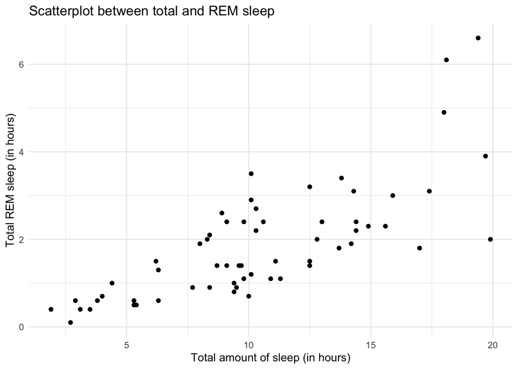

```r
ggplot(msleep, aes(x = sleep_total, y = sleep_rem)) +
  geom_point() +
  labs(title = "Scatterplot between total and REM sleep",
       x = "Total amount of sleep (in hours)",
       y = "Total REM sleep (in hours)") +
  theme_minimal()
```

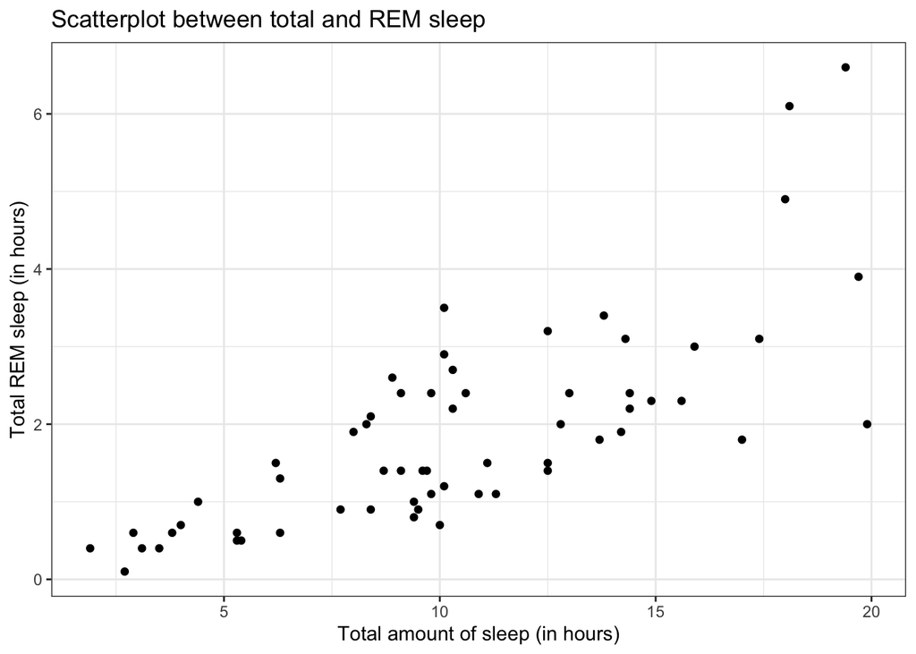

```r
ggplot(msleep, aes(x = sleep_total, y = sleep_rem)) +
  geom_point() +
  labs(title = "Scatterplot between total and REM sleep",
       x = "Total amount of sleep (in hours)",
       y = "Total REM sleep (in hours)") +
  theme_bw()
```

## Grader and Regrade Requests

- Peter Ozo-Ogueji will be grading your homework assignments for the rest of the course.
- For any question or regrade requests, please email Peter directly via `po3783a@american.edu`
- I will update our syllabus later this week to include his information.

Let us quickly visit our Canvas site to revisit uploaded files to ensure we are in 100% alignment in content structure.

## Today’s Agenda

1. Chapter 2: R Workflow (Assignment Operators, Naming Objects, Functions)
2. Chapter 3: Introduction to the dplyr package (part of tidyverse packages) for data manipulation and summary creation.

**Note:** As a working data scientist for years, I know for a fact that the dplyr package is the tool you’ll use the most as a data scientist who works with real world data.

## R Workflow: Assignment Operator

In lecture 1, we discussed performing basic operations (e.g., arithmetic, logical).

Now, let us introduce the idea of assignment operators (**<-**), which allows you to save data in your R environment. We generally refer to saved information in your R environment as **R objects**.

For example, running the script below would create a variable called **multiplication_example** in your R environment:

```r
multiplication_example <- 2*3
```

In effect, the right side of the code calculates a value (here, 2*3 = 6), then assigns/saves that value as **multiplication_example** in your R environment.

## Printing data from your R environment

Running an R script using variable names (e.g., **multiplication_example** we created previously) saved within your R environment would print the contained data.

Running **multiplication_example** as an R script below would print the contained data:

```r
multiplication_example
```

```
## [1] 6
```

## Saving values for later use

You may save values as variables or R objects.

Earlier code:

```r
first_value <- 9
second_value <- 5 * 2
```

Later code:

```r
first_value + second_value
```

```
## [1] 19
```

## Case sensitivity

Please note the variables saved in R are case-sensitive. Earlier, we created **multiplication_example**.

Attempting to run **MULTIPLICATION_EXAMPLE** in an R script or R chunk would give you the following R error message:

```r
MULTIPLICATION_EXAMPLE
```

```
## Error in eval(expr, envir, enclos): object 'MULTIPLICATION_EXAMPLE' not found
```

**Note:** The lecture slides cut off the entire error message which in full states: Error: object ‘MULTIPLICATION_EXAMPLE’ not found

## Convention: Naming R Objects

R object names must start with a letter. And may contain additional letters, numbers, _ (underscore), and . (period).

For example, here are examples of **allowed** object names, though **not necessarily best practices**, in R:

- i_use_snake_case
- otherPeopleUseCamelCase
- some.people.use.periods
- And_aFew.People_RENOUNCEconvention

## Convention: Naming R Objects

**Convention and best practices in R I expect you to use:**

Although examples above demonstrated what is allowed, we follow a commonly accepted convention within the R community.

- For R objects created by assignment operator (i.e., **<-**) into the R environment, you should only use lowercase letters, numbers, and `_` (underscore).
- Use `_` (underscore) to separate words within a name (e.g., **nebraska_flights**).
- Make sure your variable/object name is meaningful. For example, if the data you want to save in your R environment pertains to cancer patient data, saving the data as **cancer_patient** in your R environment could be an excellent choice.

## Functions

A function is a block of code which only runs when it is called. They generally do meaningful jobs. You typically call functions using this format:

```r
function_name(argument1 = value1, argument2 = value2, ...)
```

Although functions is barely covered in Chapter 2 of your textbook, we have used many functions already.

For example, **head()** is a function from base R (meaning it is built-in with R). **glimpse()** is another function from one of the tidyverse packages.

## Functions: Arguments

As shown in the previous slides, functions can accept multiple arguments:

```r
function_name(argument1 = value1, argument2 = value2, ...)
```

We previously used **head()** before to print a sample of our data. For example, we’ve run the following scripts:

```r
library(tidyverse) # loads the tidyverse packages
data("diamonds") # loads the diamonds data into the R env't
head(diamonds) # prints the first six rows of the built-in diamonds data
```

```
## # A tibble: 6 × 10
##   carat cut       color clarity depth table price     x     y     z
##   <dbl> <ord>     <ord> <ord>   <dbl> <dbl> <int> <dbl> <dbl> <dbl>
## 1  0.23 Ideal     E     SI2      61.5    55   326  3.95  3.98  2.43
## 2  0.21 Premium   E     SI1      59.8    61   326  3.89  3.84  2.31
## 3  0.23 Good      E     VS1      56.9    65   327  4.05  4.07  2.31
## 4  0.29 Premium   I     VS2      62.4    58   334  4.2   4.23  2.63
## 5  0.31 Good      J     SI2      63.3    58   335  4.34  4.35  2.75
## 6  0.24 Very Good J     VVS2     62.8    57   336  3.94  3.96  2.48
```

In your R console, run either one of the following scripts: **?head** or **help(head)** .

Let us look at the documentation that appears in your Help pane.

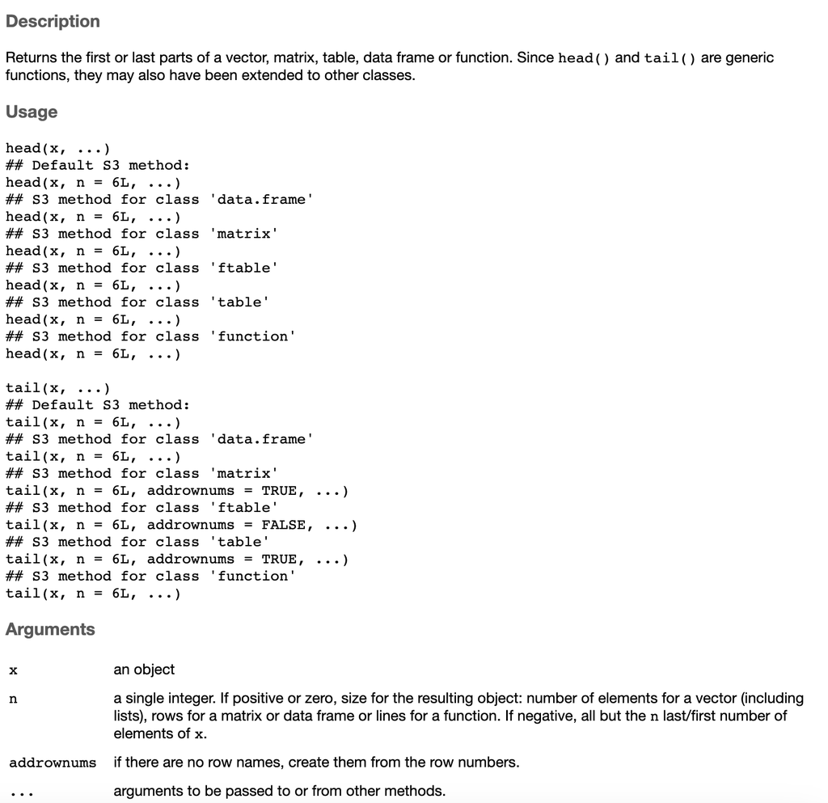

Figure 1. Documentation that should appear in your help pane after running scripts from previous page in your R Console.

## Functions: Arguments

Let us pay attention to the first two arguments and the order they are shown.

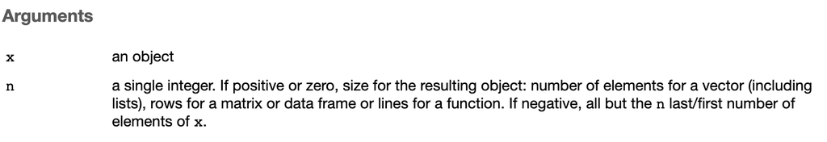

Figure 2. First two arguments accepted by head().

Here is an example script where you specifically asks **head()** to print only the first two rows of the **diamonds** data:

```r
head(x = diamonds, n = 2)
```

```
## # A tibble: 2 × 10
##   carat cut     color clarity depth table price     x     y     z
##   <dbl> <ord>   <ord> <ord>   <dbl> <dbl> <int> <dbl> <dbl> <dbl>
## 1  0.23 Ideal   E     SI2      61.5    55   326  3.95  3.98  2.43
## 2  0.21 Premium E     SI1      59.8    61   326  3.89  3.84  2.31
```

## Functions: Arguments

Now ask yourself, why did **head(diamonds)** work previously in previous classes?

**AGAIN:** Let us pay attention to the first two arguments and the order they are shown within the documentation.

Since **x** (which accepts the R object data saved within your R env’t) is the first argument within the arguments list from the documentation, R assumes that by running **head(diamonds)**, you want R to assume that you want to feed **diamonds** into **x** since **x** is the first argument within the documentation.

*The order of the arguments in the documentation matters*.

Running **head(diamonds, 2)** is equivalent to running **head(x = diamonds, n = 2)**. The same idea holds: since you listed **2** as the second argument within **head(diamonds, 2)**, R will assign the value to the second argument from the documentation which is **n**.

We will do a hands-on demo on the dplyr package.

Before we proceed, make sure to run the following script in your R Console:

```r
install.packages("nycflights13")
```

After installing the package, download Data312Exercise3.qmd from Canvas and open the Quarto Document in Canvas.